# Guest Lecture for PPS 3250

The Effect of Same-Sex Marriage Legalization on Adoptions & Family Formation

Joshua C. Martin

joshua.martin@vanderbilt.edu

Vanderbilt University

February 21, 2024

## Identifying a research topic

### Pay Attention to What You Pay Attention To

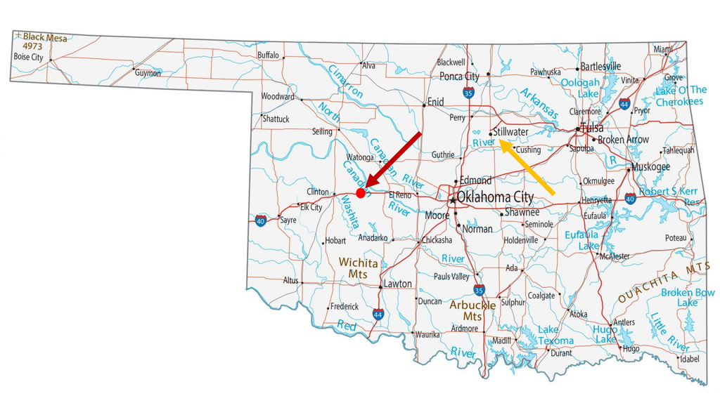

## Identifying a research topic

### Pay Attention to What You Pay Attention To

[figure not shown]

## Identifying a research topic

### Pay Attention to What You Pay Attention To

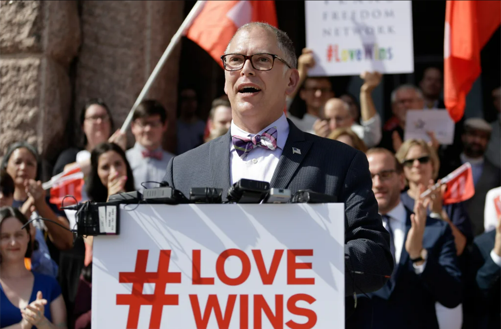

## Identifying a research topic

### Pay Attention to What You Pay Attention To

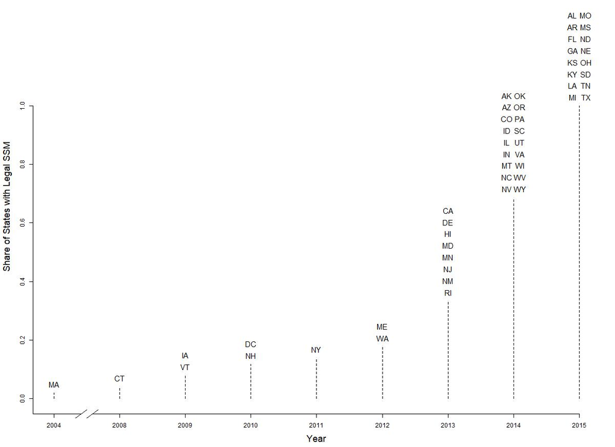

## Identifying a research topic

### Pay Attention to What You Pay Attention To

[figure not shown]

## Identifying a research topic

### Pay Attention to What You Pay Attention To

[figure not shown]

[figure not shown]

## Identifying a research topic

### Pay Attention to What You Pay Attention To

[figure not shown]

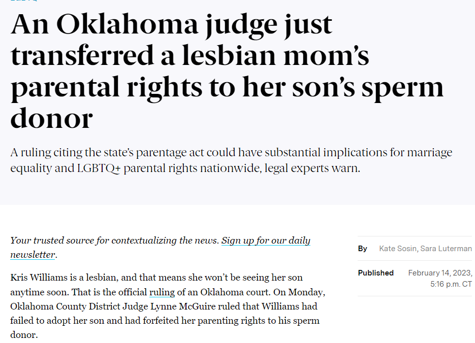

## Identifying a research topic

### Pay Attention to What You Pay Attention To

[figure not shown]

## Identifying a research topic

### Pay Attention to What You Pay Attention To

[figure not shown]

## Identifying a research topic

### Find Inspiration

[figure not shown]

## Identifying a research topic

### Find Inspiration

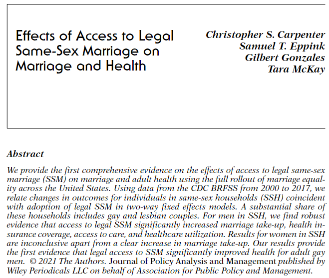

## Identifying a research topic

### Theorizing the relationship

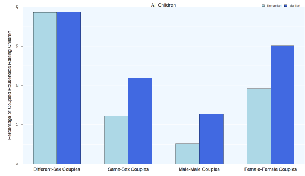

## Identifying a research topic

### Theorizing the relationship

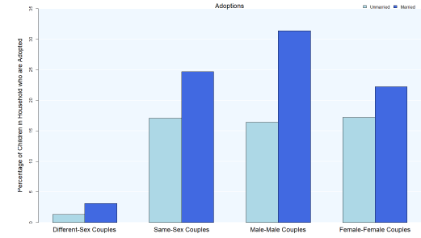

## Data

### Finding the data

[figure not shown]

## Data

### Cleaning the data

- 25m $\times$ 200 data frame
- What level *should* the analysis ideally be preformed at?
- What level *can* the analysis be preformed at?

## Data

### Creating a panel dataset

- Assign a date for everyone
  - Date of discharge
  - Current date
  - Latest date
  - First removed
- Time in foster care = Date – first removed

## Data

### Creating a panel dataset

- I chose to aggregate the data
  1. Computational simplicity
  2. Controling for the population of children in foster care

## Data

### Dependent variables

- Data frame creation (County by State by Year)
- Tabulation = number of children interacting with the foster care system per year
  - Total Discharges = Aggregate number of individuals with any “discharge reason”
  - Parental Reunifications
  - Adoptions = living with Other relatives, adoption or guardianship
  - “Bad” Discharges = emancipation, transfer to Another Agency, runaway, or death
  - Still in system = foster care – total discharges

## Early Work

### Research is a trial and error process

- I bit off more than I could chew – simultaneously studing the impact of:
  - Same-sex marriage, Domestic partnership / civil unions, Legislative Bans, Constitutional Bans
- Extrapolated evidence that I did not provide
- I introduced a “novel” new empirical method
  - 25% of the paper was methods

[figure not shown]

## Early Work

### Research is a trial and error process

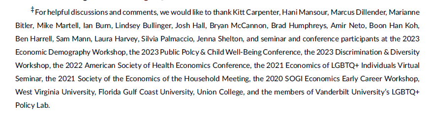

## Early Work

### Research is a trial and error process

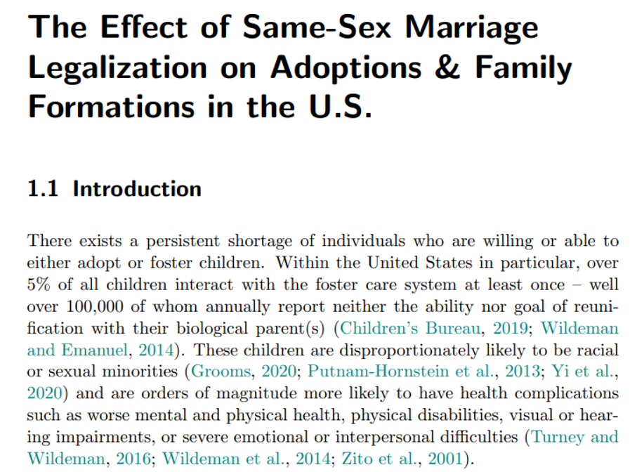

## Early Work

### Research is a trial and error process

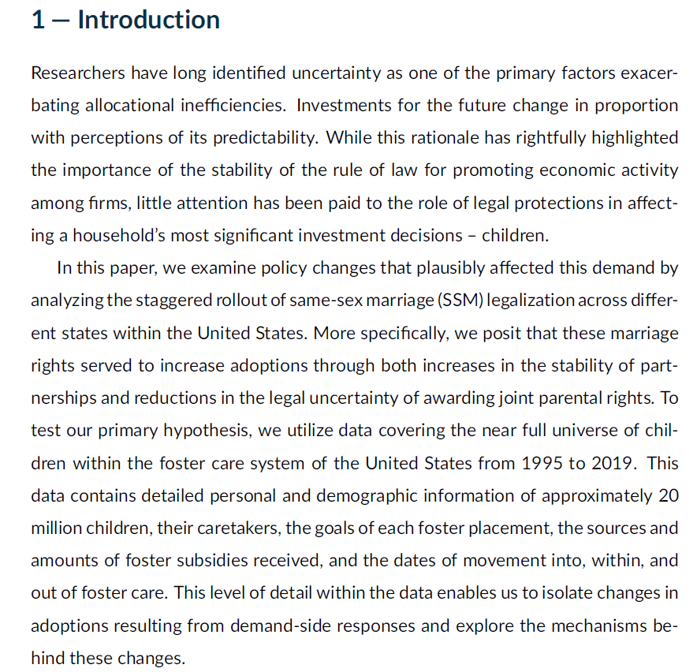

## Data

### Plot it out

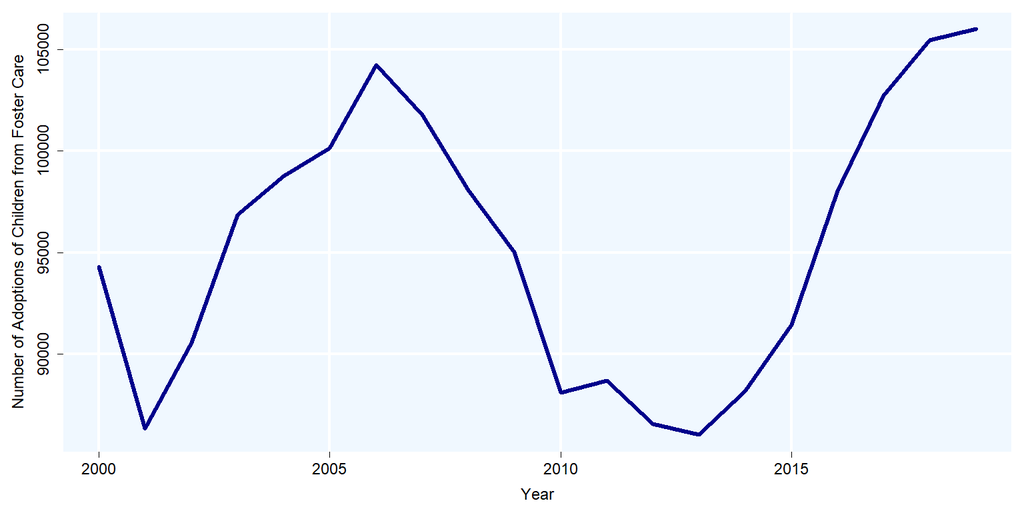

## Data

### Plot it out

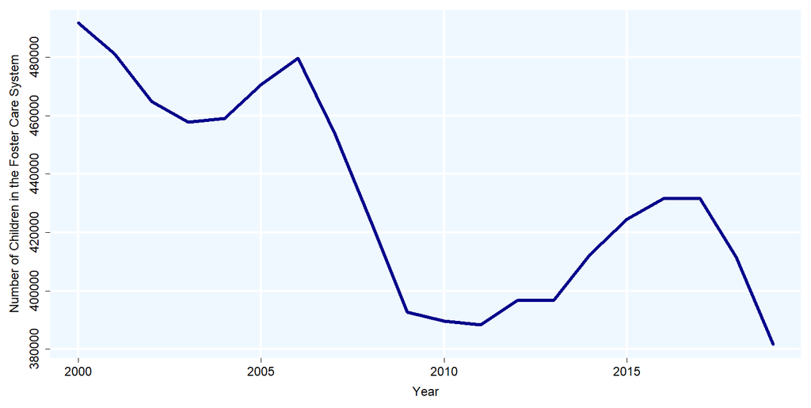

## Data

### Plot it out

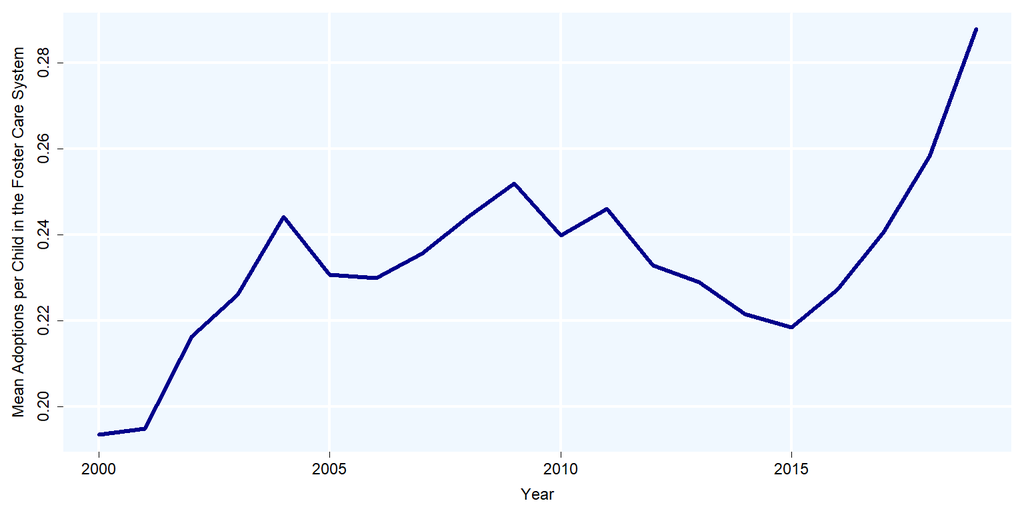

## Analysis

### Plot it out

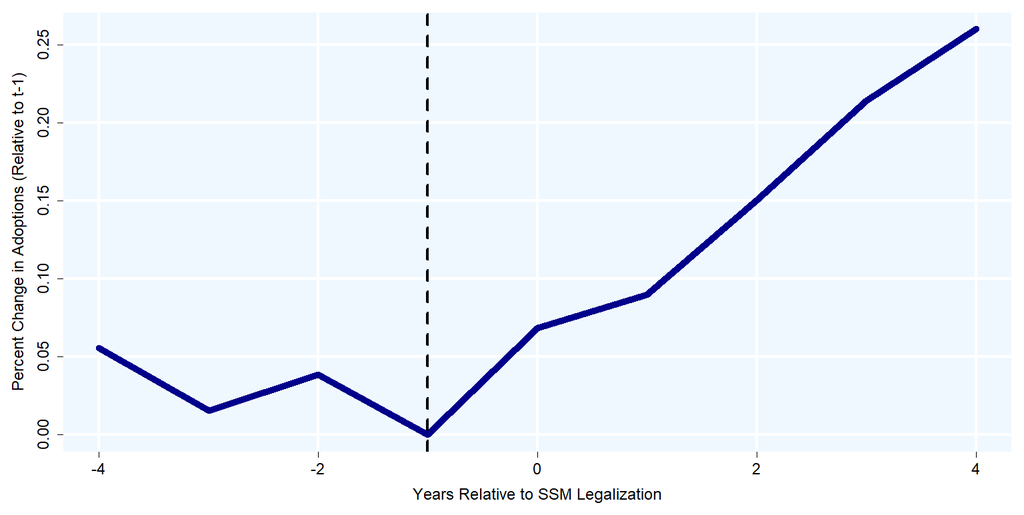

## Analysis

### Plot it out

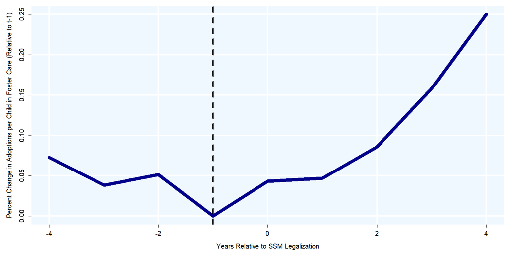

## In-Class Exercise

### Massachusetts & Vermont

- What is the appropriate “time window”
  - All states eventually legalize SSM
- Do we need to omit any “treated” states from this time window?
- Create an indicator variable for “treatment” (SSM)
- What dependent variable should we use?
- Do we need any control variables